# Analysis for item wording effects project

Last updated 2021-07-11

# Workspace

```r
library(here) # for working with files
library(tidyverse) # for cleaning
library(janitor) # for variable names
library(lme4) # for mulitlevel modeling
library(sjPlot) # for figures
library(ggpubr) # for prettier plots
library(kableExtra) # for nicer tables
```

```r
data_labels = read_csv(here("data/Wording_July+11,+2021_17.17.csv"))

data = read_csv(here("data/Wording_July+11,+2021_17.17.csv"),
                skip = 3, col_names = names(data_labels))
rm(data_labels)
data = clean_names(data)
```

Remove the following columns.

```r
data = data %>%
  select(-end_date,
         -ip_address,
         -progress,
         -duration_in_seconds,
         -finished,
         -recorded_date,
         -external_reference,
         -distribution_channel,
         -user_language,
         -starts_with("recipient"),
         -starts_with("location"),
         -starts_with("meta_info"))
```

# Cleaning

## Recode personality item responses to numeric

We recode the responses to personality items, which we downloaded as text strings.

```r
contains_accurate = apply(data, 2, FUN = function(x) str_detect(x, "accurate"))
contains_accurate = apply(contains_accurate, 2, sum, na.rm=T)
contains_accurate = names(data)[contains_accurate > 0]
personality_items = select(data, proid, all_of(contains_accurate))
```

Next we write a simple function to recode values.

```r
recode_p = function(x){
  y = case_when(
    x == "Very inaccurate" ~ 1,
    x == "Moderately inaccurate" ~ 2,
    x == "Slightly inaccurate" ~ 3,
    x == "Slightly accurate" ~ 4,
    x == "Moderately accurate" ~ 5,
    x == "Very accurate" ~ 6,
    TRUE ~ NA_real_)
  return(y)
}
```

Finally, we apply this function to all personality items.

```r
personality_items = personality_items %>%
  mutate(
    across(!c(proid), recode_p))
```

Now we merge this back into the data.

```r
data = select(data, -all_of(contains_accurate))
data = full_join(data, personality_items)
```

# Analyses

## Format effect

### Data prep

**We will use between-person analyses to compare responses using group-level data for the different formats.**

First we select the responses to the items of different formats. These variable names all have the same format: `[trait]_[abcd]` (for example, `talkative_a`). We search for these items using regular expressions.

```r
items_seen_first = str_subset(
  names(data),
  "^([[:alpha:]])+_[abcd]$"
)

item_responses = data %>%
  select(proid, all_of(items_seen_first))
```

Next we reshape these data into long form.

```r
item_responses = item_responses %>%
  gather(item, response, -proid) %>%
  separate(item, into = c("item", "format")) %>%
  filter(!is.na(response))
```

### Results

```r
mod.format = lmer(response~format + (1|proid),
                  data = item_responses)
anova(mod.format)
```

```
## Analysis of Variance Table
##        npar Sum Sq Mean Sq F value
## format    3 201.17  67.056  39.017
```

[figure not shown]

```r
plot_model(mod.format, type = "pred")
```

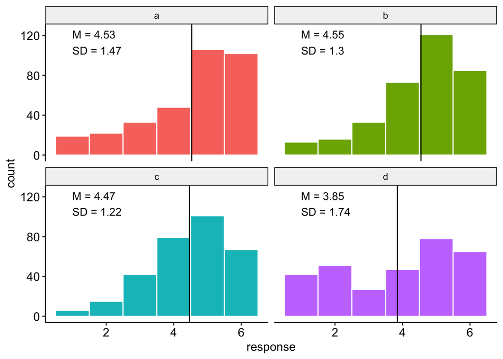

```r
means_by_group = item_responses %>%
  group_by(format) %>%
  summarise(m = mean(response),
            s = sd(response))

item_responses %>%
  ggplot(aes(x = response, fill = format)) +
  geom_histogram(bins = 6, color = "white") +
  geom_vline(aes(xintercept = m), data = means_by_group) +
  geom_text(aes(x = 1,
                y = 125,
                label = paste("M =", round(m,2),
                              "\nSD =", round(s,2))),
            data = means_by_group,
            hjust =0,
            vjust = 1) +
  facet_wrap(~format) +
  guides(fill = F) +
  theme_pubr()
```

We can also repeat this analysis separately for each trait.

```r
mod_by_item = item_responses %>%
  group_by(item) %>%
  nest() %>%
  mutate(mod = map(data, ~lm(response~format, data = .))) %>%
  mutate(aov = map(mod, anova))

mod_by_item %>%
  mutate(tidy = map(aov, broom::tidy)) %>%
  select(item, tidy) %>%
  unnest(cols = c(tidy)) %>%
  filter(term == "format") %>%
  mutate(p.adj = p.adjust(p.value, method = "holm")) %>%
  mutate(across(
    starts_with("p"),
    papaja::printnum
  )) %>%
  kable(digits = 2, booktabs = T) %>%
  kable_styling()
```

| item | term | df | sumsq | meansq | statistic | p.value | p.adj |
| --- | --- | --- | --- | --- | --- | --- | --- |
| outgoing | format | 3 | 3.56 | 1.19 | 0.77 | 0.52 | 0.52 |
| helpful | format | 3 | 4.97 | 1.66 | 1.15 | 0.34 | 0.34 |
| reckless | format | 3 | 5.53 | 1.84 | 0.79 | 0.51 | 0.51 |
| moody | format | 3 | 11.29 | 3.76 | 2.34 | 0.09 | 0.09 |
| organized | format | 3 | 7.21 | 2.40 | 1.54 | 0.22 | 0.22 |
| friendly | format | 3 | 6.10 | 2.03 | 2.25 | 0.10 | 0.10 |
| warm | format | 3 | 4.38 | 1.46 | 0.85 | 0.47 | 0.47 |
| responsible | format | 3 | 8.89 | 2.96 | 2.36 | 0.09 | 0.09 |
| lively | format | 3 | 2.52 | 0.84 | 0.66 | 0.58 | 0.58 |
| asleep | format | 3 | 3.61 | 1.20 | 0.50 | 0.68 | 0.68 |
| caring | format | 3 | 3.30 | 1.10 | 1.01 | 0.40 | 0.40 |
| nervous | format | 3 | 3.66 | 1.22 | 0.52 | 0.67 | 0.67 |
| creative | format | 3 | 0.81 | 0.27 | 0.20 | 0.90 | 0.90 |
| hardworking | format | 3 | 6.92 | 2.31 | 1.70 | 0.18 | 0.18 |
| imaginative | format | 3 | 0.84 | 0.28 | 0.23 | 0.87 | 0.87 |
| softhearted | format | 3 | 8.38 | 2.79 | 1.53 | 0.22 | 0.22 |
| calm | format | 3 | 7.37 | 2.46 | 2.07 | 0.12 | 0.12 |
| intelligent | format | 3 | 2.48 | 0.83 | 0.40 | 0.75 | 0.75 |
| curious | format | 3 | 3.38 | 1.13 | 1.02 | 0.39 | 0.39 |
| active | format | 3 | 8.22 | 2.74 | 1.66 | 0.19 | 0.19 |
| human | format | 3 | 8.26 | 2.75 | 1.96 | 0.14 | 0.14 |
| careless | format | 3 | 9.73 | 3.24 | 1.37 | 0.27 | 0.27 |
| impulsive | format | 3 | 3.92 | 1.31 | 0.80 | 0.50 | 0.50 |
| sympathetic | format | 3 | 9.52 | 3.17 | 2.75 | 0.06 | 0.06 |
| cautious | format | 3 | 12.01 | 4.00 | 2.16 | 0.11 | 0.11 |
| talkative | format | 3 | 13.92 | 4.64 | 2.34 | 0.09 | 0.09 |
| sophisticated | format | 3 | 1.99 | 0.66 | 0.46 | 0.71 | 0.71 |
| adventurous | format | 3 | 3.91 | 1.30 | 1.19 | 0.33 | 0.33 |
| thorough | format | 3 | 0.69 | 0.23 | 0.19 | 0.90 | 0.90 |
| thrifty | format | 3 | 10.75 | 3.58 | 2.86 | 0.05 | 0.05 |
| worrying | format | 2 | 7.63 | 3.82 | 1.72 | 0.20 | 0.20 |

**These analyses will attempt to account for memory effects by collecting data on immediate and delayed recall (5 minutes and approximately two weeks) using a memory paradigm that was developed based on a similar recall task used in the HRS (Runge et al., 2015).**

Within-person analyses will model the proportions of variance attributable to item format, stems of the items (i.e., the content of the adjectives), and the respondent-level variance.

We will also consider the effect on retest reliability of performance on the word recall task.

We will further compare response times as a function of item format using both within- and between-person data in order to evaluate the presumption that adjective ratings require less time than phrased items.

Finally, secondary analyses will consider preliminary evidence for differences (e.g., mean response times, mean level of response) based on the type of device used to complete the survey (mobile, desktop, or tablet).